# GSEAdv: Evaluate

Lluís Revilla

August Pi i Sunyer Biomedical Research Institute (IDIBAPS); Liver Unit, Hospital Clinic

lrevilla@clinic.cat

14 September 2018

#### Abstract

Shows the methods and functions used to evaluate the relationship between genes and gene sets.

#### Package

GSEAdv 0.1.0

# 1 Introduction

This vignette assumes that the reader is familiar with the infraestructure build in Bioconductor around gene sets, mainly *GSEABase*. It provides examples of how to use the package to understand the relationships between genes and gene sets.

# 2 Distribution of genes and pathways by size:

This functions calculate for each gene or pathway how are their elements distributed:

```r
sizeGenes(Info)
##               Gene
## genePerPathway 10 2 3 9
##              2  3 1 1 3
##              3  1 0 1 1
sizePathways(Info)
##                Pathway
## pathwaysPerGene 1430728 156580 156582 194840 211859
##               1       0      0      0      1      0
##               2       0      1      0      1      0
##               4       2      2      2      0      2
```

We can see that genes are distributed in pathways of size 2 or 3, but pathways have genes in either 1, 2 or 4 pathways. If we are only interested in how many different sizes they are distributed we can use the following functions:

These two functions evaluate how many elements of different length they are involved in

```r
sizesPerGene(Info)
## 10  2  3  9
##  2  1  2  2
sizesPerPathway(Info)
## 1430728  156580  156582  194840  211859
##       1       2       1       2       1
```

# 3 Relationships between pathways

Sometimes some databases due to different reasons use the same genes to describe different pathways or use all the genes in a pathway to describe another pathway. To find those cases we can use the function `nested`:

```r
nested(Info)
##         1430728 156580 156582 194840 211859
## 1430728       1      1      1      0      1
## 156580        0      1      0      0      0
## 156582        1      1      1      0      1
## 194840        0      0      0      1      0
## 211859        1      1      1      0      1
```

Here we can see that pathway “156582” and “211859” are inside the “1430728”. If you look carefully you’ll see that the matrix is not symmetric. That is because the pathways on the rows are in the pathways in the columns. So, pathway “156580” includes pathway “1430728” (and therefore pathways “156582” and “211859”) and pathway “156580”.

## 3.1 Duplicated pathways

This might mean that some pathways are duplicated. To check this there is the function `duplicatedPathways`:

```r
duplicatedPathways(Info)
## [1] TRUE
```

And conversively the `duplicatedGenes` function, checks if some genes are described as the same combination of pathways :

```r
duplicatedGenes(Info)
## [1] TRUE
```

If we want to check if a GeneSetCollection is not a group of isolated genes without relation between different gene sets we can use the function `isolation`

```r
isolation(gss)
## [1] FALSE
isolation(Info)
## [1] FALSE
```

# 4 Relationships between number of genes per pathway and number of pathways per gene

To see what is the conditional probability between the number of pathways gene in n number of pathways are involved $P( pathways_{genes} | genes_{pathway} )$ there is the function `condPerGene`. While the oposite $P( genes_{pathway} | pathways_{genes} )$) can be done with `condPerPathways`

```r
condPerGenes(Info)
##                genesPerPathway
## pathwaysPerGene     2         3
##               1 0.125 0.0000000
##               2 0.125 0.3333333
##               4 0.750 0.6666667
condPerPathways(Info)
##                pathwaysPerGene
## genesPerPathway 1   2    4
##               2 1 0.5 0.75
##               3 0 0.5 0.25
```

# 5 Style macros

*BiocStyle* introduces the following macros for referring to *R* packages:

- *IRanges*, for *Bioconductor* software, annotation and experiment data packages,
- *data.table*, for *R* packages available on CRAN,
- *rmarkdown*, for *R* packages available on GitHub,
- *MyPkg*, for *R* packages that are *not* available on *Bioconductor*, CRAN or GitHub.

# 6 Figures

Assign captions to figures in the code chunk option `fig.cap` to automatically number them, and to be able to reference them, see Figure 1. The figure label is generated from the code chunk label by prefixing it with `fig:`.

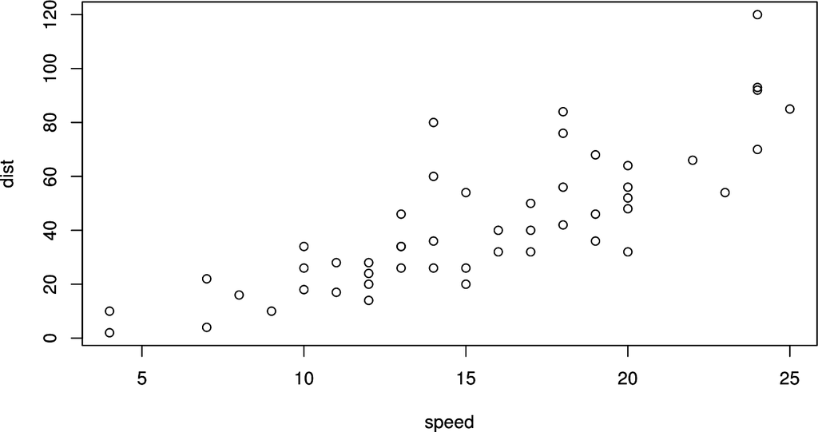

Figure 1: Regular figure  
The first sentence of the figure caption is automatically emphasized to serve as figure title.

Small and wide figures can be specified by `fig.small` and `fig.wide` code chunk options.

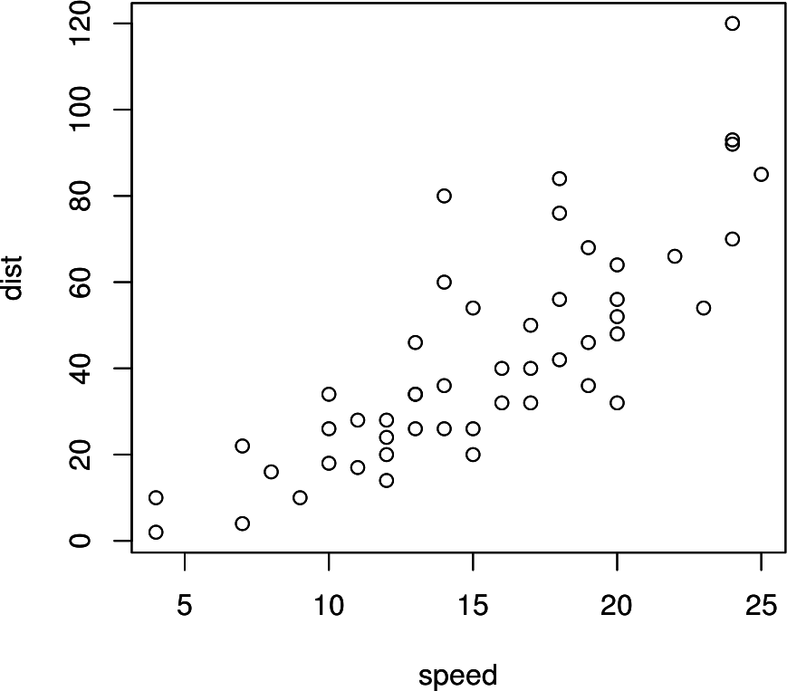

Figure 2: Small figure  
A plot produced by a code chunk with option `fig.small = TRUE`.

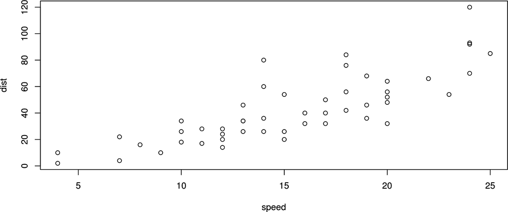

Figure 3: Wide figure  
A plot produced by a code chunk with option `fig.wide = TRUE`.

# 7 Equations

# 8 Tables

Like figures, tables with captions will also be numbered and can be referenced, see Table 1.

Table 1: A simple table With caption.

| Fruit | Price |
| --- | --- |
| bananas | 1.2 |
| apples | 1.0 |
| oranges | 2.5 |

# 9 Cross-references

Apart from referencing figures (Section 6), tables (Section 8), and equations (Section 7), you can also use the same syntax to refer to sections by their default labels generated by pandoc.

# 10 Side notes

Footnotes are displayed as side notes on the right margin, which has the advantage that they appear close to the place where they are defined.

this is a side note entered as a footnote